# Single metrics

Justin Pomeranz

## Overview

This tutorial will show how to calculate simple biomonitoring metrics from community data. It will begin with analyzing data form a single site, and then we will look at calculating individual metrics for multiple sites at a time.

## Introduction

Community data is multifaceted and complex; a simple list of taxa can be expanded to include information on taxonomy and systematics, as well as trait data such as functional feeding groups (FFG), modes of existence, pollution tolerance, life history attributes, in addition to others.

Typically, metrics are organized into a few categories such as:

1. Structural
2. Composition
3. Life history

Analyzing data in spreadsheet software such as Microsoft Excel is not overly difficult, although it can be tedious and error-prone. Most frustratingly, it can be extremely difficult to proofread and find/correct errors in excel formulas. These difficulties are compounded when trying to analyze data from multiple sites at once, which is a typical demand of biomonitoring studies.

For this reason, we will be learning the data and statistical language called R. Learning R, like learning any new language, is time-consuming and can be quite difficult, especially at the beginning. However, this is an important skill which is increasingly in demand in the job market. Every minute you spend learning it now will likely save you many minutes if not hours in the future, so it is well worth your time.

As they say in Australia:

> Don’t be so busy digging a hole with a spoon that you don’t take the time to go and get a shovel.

Be kind to your future self and take the time to learn how to use a shovel now.

## Data

We are going to be working with data collected by [Mountain Studies Institute](https://www.mountainstudies.org/) after the [2015 Gold King Mine](https://en.wikipedia.org/wiki/2015_Gold_King_Mine_waste_water_spill) spill into the Animas River.

You can find the data stored in an excel workbook on the D2L site for our course. The data is called `MMI_HW_data.xlsx`

### Data structure

1. `A75CC`
- Macroinvertebrate community data from a single site
2. `A72`
- Macroinvertebrate community data from a single site
3. `taxa_info`
- This sheet has taxonomic, FFG, and habit information for all taxa in the complete data set.
4. `other_sites`
- This sheet has macroinvertebrate community data for all other sites that MSI sampled that we will be looking at for this tutorial and the associated homework assignment.
5. `site_info`
- This last sheet has information on the sites (one row per site) which includes the site_code, site name, what river it’s located on, the distance downstream (for Animas River sites only), and the impact category (reference or impacted)

## R

You should have already downloaded R and RStudio (in that order) on your personal laptops, or you are using a departmental computer which has it downloaded already.

Either way, we need to prepare the workspace before we begin.

- Start by opening Rstudio
- Follow along in class to create a project called `ENVS337`
- The most important pat is under Tools > Global Options make sure to set “save workspace to .Rdata” to Never.
  - If you missed class, there should be a panopto recording of how to do this
  - Or, you can watch [this video](https://jpomz.github.io/ENVS396-FA-2024/lessons/Introduction-to-course/) from a related course explaining the process.
- In your console, copy and run the following lines of code. Note that you only need to do this **once** per machine.
  - `install.packages("tidyverse")`
  - `install.packages("readxl")`
- Once this is done, open a new script and put the following lines of code at the top.

```r
library(readxl)
library(tidyverse)
```

- You run the individual lines of code by putting your cursor on the line and then pressing `ctrl` + `enter`
- You must run the `library()` commands **every time you open Rstudio**
- The `library()` commands make the functions within those packages available to use in your RStudio session

## Getting the data into R

```r
site1 <- read_excel("data/MMI_HW_data.xlsx",
                    sheet = "A75CC")
taxa_info <- read_excel("data/MMI_HW_data.xlsx",
                        sheet = "taxa_info")
```

- Look at the first few rows of data by putting it in the `head()` function

```r
head(site1)
```

```
## # A tibble: 6 × 3
##   site_code Taxon            Count
##   <chr>     <chr>            <dbl>
## 1 A75CC     Ameletus             1
## 2 A75CC     Baetis              52
## 3 A75CC     Drunella_doddsii    29
## 4 A75CC     Drunella_grandis     6
## 5 A75CC     Ephemerella          6
## 6 A75CC     Cinygmula            7
```

```r
head(taxa_info)
```

```
## # A tibble: 6 × 10
##   Taxon         Phylum    Class   Order  Family Genus Habit FFG   sensitive_taxa
##   <chr>         <chr>     <chr>   <chr>  <chr>  <chr> <chr> <chr> <lgl>
## 1 Ameletus      Arthropod Insecta Ephem… Amele… Amel… clin… scra… TRUE
## 2 Atherix       Arthropod Insecta Dipte… Ather… Athe… spra… pred… FALSE
## 3 Baetis        Arthropod Insecta Ephem… Baeti… Baet… swim… coll… FALSE
## 4 Bibiocephala  Arthropod Insecta Dipte… Bleph… Bibi… clin… scra… FALSE
## 5 Brachycentrus Arthropod Insecta Trich… Brach… Brac… clin… filt… FALSE
## 6 Capnia        Arthropod Insecta Pleco… Capni… Capn… spra… shre… FALSE
## # ℹ 1 more variable: Bio2_sensitive <lgl>
```

- We will now “join” the two objects together this way

```r
site_taxa <- left_join(site1, taxa_info)
head(site_taxa)
```

```
## # A tibble: 6 × 12
##   site_code Taxon            Count Phylum   Class Order Family Genus Habit FFG
##   <chr>     <chr>            <dbl> <chr>    <chr> <chr> <chr>  <chr> <chr> <chr>
## 1 A75CC     Ameletus             1 Arthrop… Inse… Ephe… Amele… Amel… clin… scra…
## 2 A75CC     Baetis              52 Arthrop… Inse… Ephe… Baeti… Baet… swim… coll…
## 3 A75CC     Drunella_doddsii    29 Arthrop… Inse… Ephe… Ephem… Drun… clin… scra…
## 4 A75CC     Drunella_grandis     6 Arthrop… Inse… Ephe… Ephem… Drun… clin… scra…
## 5 A75CC     Ephemerella          6 Arthrop… Inse… Ephe… Ephem… Ephe… clin… coll…
## 6 A75CC     Cinygmula            7 Arthrop… Inse… Ephe… Hepta… Ciny… clin… scra…
## # ℹ 2 more variables: sensitive_taxa <lgl>, Bio2_sensitive <lgl>
```

## Taxa metrics

### Total Richness

- Let’s first calculate a very simple structural metric: the richness or number of taxa

```r
site_taxa|>
  distinct(site_code, Taxon) |>
  group_by(site_code) |>
  summarize(tot_rich = n())
```

```
## # A tibble: 1 × 2
##   site_code tot_rich
##   <chr>        <int>
## 1 A75CC           44
```

- the above code starts with our data object, `site_taxa`.
- then , it looks at all the `distinct()` taxa within each site_code in the data
  - This is actually an extra step because there are no repeated taxa in this object, and there’s only one site
  - However, it’s a good idea to do that just in case, especially later when we have many sites to look at at one time.
- then, it summarizes (`summarize()`) the data by counting (`n()`) the number of rows in it.
- notice that the `|>` (also sometimes shown as a `%>%`) is a special operator called a pipe.
  - whenever I see a pipe, I say the word “then”.
- When we do that, R runs the functions and prints the result to the console, but it’s not actually saved anywhere
- to save it, we need to give it a name and use the assign operator (`<-`)
  - The shortcut for the assign operator is `alt` + `-`

```r
total_rich <- site_taxa|>
  distinct(site_code, Taxon) |>
  group_by(site_code) |>
  summarize(tot_rich = n())

total_rich
```

```
## # A tibble: 1 × 2
##   site_code tot_rich
##   <chr>        <int>
## 1 A75CC           44
```

### Ephemeroptera Richness

- Now we will do another common metric, which is just a slight bit harder to calculate: the number of Ephemeroptera taxa
- We will use much of the same code as before, but first we need to “filter” the data so that only the Ephemeroptera are present

```r
site_taxa %>%
  filter(Order == "Ephemeroptera")
```

```
## # A tibble: 8 × 12
##   site_code Taxon            Count Phylum   Class Order Family Genus Habit FFG
##   <chr>     <chr>            <dbl> <chr>    <chr> <chr> <chr>  <chr> <chr> <chr>
## 1 A75CC     Ameletus             1 Arthrop… Inse… Ephe… Amele… Amel… clin… scra…
## 2 A75CC     Baetis              52 Arthrop… Inse… Ephe… Baeti… Baet… swim… coll…
## 3 A75CC     Drunella_doddsii    29 Arthrop… Inse… Ephe… Ephem… Drun… clin… scra…
## 4 A75CC     Drunella_grandis     6 Arthrop… Inse… Ephe… Ephem… Drun… clin… scra…
## 5 A75CC     Ephemerella          6 Arthrop… Inse… Ephe… Ephem… Ephe… clin… coll…
## 6 A75CC     Cinygmula            7 Arthrop… Inse… Ephe… Hepta… Ciny… clin… scra…
## 7 A75CC     Epeorus             65 Arthrop… Inse… Ephe… Hepta… Epeo… clin… scra…
## 8 A75CC     Rhithrogena         20 Arthrop… Inse… Ephe… Hepta… Rhit… clin… scra…
## # ℹ 2 more variables: sensitive_taxa <lgl>, Bio2_sensitive <lgl>
```

- The `filter()` command looks for rows inside of the `Order` column which are equal to `"Ephemeroptera"`.
  - Note the two equals signs: `==`
  - read this as “is equal to”
  - one equal sign is read as “equals”, i.e., you are telling it that x = y
  - Another important filter command is `!=` which can be read as “is not equal to”.
- For example, let’s say we wanted everything *except* Ephemeroptera, we would write this:

```r
site_taxa %>%
  filter(Order != "Ephemeroptera")
```

```
## # A tibble: 32 × 12
##    site_code Taxon             Count Phylum Class Order Family Genus Habit FFG
##    <chr>     <chr>             <dbl> <chr>  <chr> <chr> <chr>  <chr> <chr> <chr>
##  1 A75CC     Capnia               14 Arthr… Inse… Plec… Capni… Capn… spra… shre…
##  2 A75CC     Sweltsa               6 Arthr… Inse… Plec… Chlor… Swel… clin… pred…
##  3 A75CC     Nemouridae_(not_…    48 Arthr… Inse… Plec… Nemou… <NA>  spra… shre…
##  4 A75CC     Hesperoperla          8 Arthr… Inse… Plec… Perli… Hesp… clin… pred…
##  5 A75CC     Isoperla              2 Arthr… Inse… Plec… Perlo… Isop… clin… pred…
##  6 A75CC     Skwala                2 Arthr… Inse… Plec… Perlo… Skwa… clin… pred…
##  7 A75CC     Taenionema            5 Arthr… Inse… Plec… Taeni… Taen… spra… shre…
##  8 A75CC     Brachycentrus         1 Arthr… Inse… Tric… Brach… Brac… clin… filt…
##  9 A75CC     Arctopsyche          45 Arthr… Inse… Tric… Hydro… <NA>  clin… filt…
## 10 A75CC     Hydropsyche          47 Arthr… Inse… Tric… Hydro… <NA>  clin… filt…
## # ℹ 22 more rows
## # ℹ 2 more variables: sensitive_taxa <lgl>, Bio2_sensitive <lgl>
```

- back to the Ephermoptera richness…

```r
site_taxa %>%
  filter(Order == "Ephemeroptera")
```

```
## # A tibble: 8 × 12
##   site_code Taxon            Count Phylum   Class Order Family Genus Habit FFG
##   <chr>     <chr>            <dbl> <chr>    <chr> <chr> <chr>  <chr> <chr> <chr>
## 1 A75CC     Ameletus             1 Arthrop… Inse… Ephe… Amele… Amel… clin… scra…
## 2 A75CC     Baetis              52 Arthrop… Inse… Ephe… Baeti… Baet… swim… coll…
## 3 A75CC     Drunella_doddsii    29 Arthrop… Inse… Ephe… Ephem… Drun… clin… scra…
## 4 A75CC     Drunella_grandis     6 Arthrop… Inse… Ephe… Ephem… Drun… clin… scra…
## 5 A75CC     Ephemerella          6 Arthrop… Inse… Ephe… Ephem… Ephe… clin… coll…
## 6 A75CC     Cinygmula            7 Arthrop… Inse… Ephe… Hepta… Ciny… clin… scra…
## 7 A75CC     Epeorus             65 Arthrop… Inse… Ephe… Hepta… Epeo… clin… scra…
## 8 A75CC     Rhithrogena         20 Arthrop… Inse… Ephe… Hepta… Rhit… clin… scra…
## # ℹ 2 more variables: sensitive_taxa <lgl>, Bio2_sensitive <lgl>
```

- This gives us all the rows where the order is equal to Ephemeroptera
- Now we can take our code from earlier and add it to get the final result

```r
ephem_rich <- site_taxa %>%
  filter(Order == "Ephemeroptera") |>
  distinct(site_code, Taxon) |>
  group_by(site_code) |>
  summarize(E_rich = n())
ephem_rich
```

```
## # A tibble: 1 × 2
##   site_code E_rich
##   <chr>      <int>
## 1 A75CC          8
```

- Now we have two separate results, so let’s combine them together.

```r
single_results <- left_join(total_rich, ephem_rich)
single_results
```

```
## # A tibble: 1 × 3
##   site_code tot_rich E_rich
##   <chr>        <int>  <int>
## 1 A75CC           44      8
```

### EPT richness

- Let’s make this a little more complex and calculate the EPT richness.
- We’ve already seen how to filter out the rows where `Order == "Ephemeroptera"`, but now we need an “OR” statement to include the other 2 orders.
- inside of `filter()`, you can use a `|` as an OR statement

```r
site_taxa %>%
  filter(Order == "Ephemeroptera" |
           Order == "Plecoptera")
```

```
## # A tibble: 15 × 12
##    site_code Taxon             Count Phylum Class Order Family Genus Habit FFG
##    <chr>     <chr>             <dbl> <chr>  <chr> <chr> <chr>  <chr> <chr> <chr>
##  1 A75CC     Ameletus              1 Arthr… Inse… Ephe… Amele… Amel… clin… scra…
##  2 A75CC     Baetis               52 Arthr… Inse… Ephe… Baeti… Baet… swim… coll…
##  3 A75CC     Drunella_doddsii     29 Arthr… Inse… Ephe… Ephem… Drun… clin… scra…
##  4 A75CC     Drunella_grandis      6 Arthr… Inse… Ephe… Ephem… Drun… clin… scra…
##  5 A75CC     Ephemerella           6 Arthr… Inse… Ephe… Ephem… Ephe… clin… coll…
##  6 A75CC     Cinygmula             7 Arthr… Inse… Ephe… Hepta… Ciny… clin… scra…
##  7 A75CC     Epeorus              65 Arthr… Inse… Ephe… Hepta… Epeo… clin… scra…
##  8 A75CC     Rhithrogena          20 Arthr… Inse… Ephe… Hepta… Rhit… clin… scra…
##  9 A75CC     Capnia               14 Arthr… Inse… Plec… Capni… Capn… spra… shre…
## 10 A75CC     Sweltsa               6 Arthr… Inse… Plec… Chlor… Swel… clin… pred…
## 11 A75CC     Nemouridae_(not_…    48 Arthr… Inse… Plec… Nemou… <NA>  spra… shre…
## 12 A75CC     Hesperoperla          8 Arthr… Inse… Plec… Perli… Hesp… clin… pred…
## 13 A75CC     Isoperla              2 Arthr… Inse… Plec… Perlo… Isop… clin… pred…
## 14 A75CC     Skwala                2 Arthr… Inse… Plec… Perlo… Skwa… clin… pred…
## 15 A75CC     Taenionema            5 Arthr… Inse… Plec… Taeni… Taen… spra… shre…
## # ℹ 2 more variables: sensitive_taxa <lgl>, Bio2_sensitive <lgl>
```

- Now we have both the mayflies and stoneflies, and we can get the caddisflies with one more or (`|`) statement

```r
site_taxa %>%
  filter(Order == "Ephemeroptera" |
           Order == "Plecoptera" |
           Order == "Trichoptera")
```

```
## # A tibble: 19 × 12
##    site_code Taxon             Count Phylum Class Order Family Genus Habit FFG
##    <chr>     <chr>             <dbl> <chr>  <chr> <chr> <chr>  <chr> <chr> <chr>
##  1 A75CC     Ameletus              1 Arthr… Inse… Ephe… Amele… Amel… clin… scra…
##  2 A75CC     Baetis               52 Arthr… Inse… Ephe… Baeti… Baet… swim… coll…
##  3 A75CC     Drunella_doddsii     29 Arthr… Inse… Ephe… Ephem… Drun… clin… scra…
##  4 A75CC     Drunella_grandis      6 Arthr… Inse… Ephe… Ephem… Drun… clin… scra…
##  5 A75CC     Ephemerella           6 Arthr… Inse… Ephe… Ephem… Ephe… clin… coll…
##  6 A75CC     Cinygmula             7 Arthr… Inse… Ephe… Hepta… Ciny… clin… scra…
##  7 A75CC     Epeorus              65 Arthr… Inse… Ephe… Hepta… Epeo… clin… scra…
##  8 A75CC     Rhithrogena          20 Arthr… Inse… Ephe… Hepta… Rhit… clin… scra…
##  9 A75CC     Capnia               14 Arthr… Inse… Plec… Capni… Capn… spra… shre…
## 10 A75CC     Sweltsa               6 Arthr… Inse… Plec… Chlor… Swel… clin… pred…
## 11 A75CC     Nemouridae_(not_…    48 Arthr… Inse… Plec… Nemou… <NA>  spra… shre…
## 12 A75CC     Hesperoperla          8 Arthr… Inse… Plec… Perli… Hesp… clin… pred…
## 13 A75CC     Isoperla              2 Arthr… Inse… Plec… Perlo… Isop… clin… pred…
## 14 A75CC     Skwala                2 Arthr… Inse… Plec… Perlo… Skwa… clin… pred…
## 15 A75CC     Taenionema            5 Arthr… Inse… Plec… Taeni… Taen… spra… shre…
## 16 A75CC     Brachycentrus         1 Arthr… Inse… Tric… Brach… Brac… clin… filt…
## 17 A75CC     Arctopsyche          45 Arthr… Inse… Tric… Hydro… <NA>  clin… filt…
## 18 A75CC     Hydropsyche          47 Arthr… Inse… Tric… Hydro… <NA>  clin… filt…
## 19 A75CC     Rhyacophila_sibi…     6 Arthr… Inse… Tric… Rhyac… Rhya… clin… pred…
## # ℹ 2 more variables: sensitive_taxa <lgl>, Bio2_sensitive <lgl>
```

- And adding the other code to get the count

```r
ept_rich <- site_taxa %>%
  filter(Order == "Ephemeroptera" |
           Order == "Plecoptera" |
           Order == "Trichoptera") |>
  distinct(site_code, Taxon) |>
  group_by(site_code) |>
  summarize(EPT_rich = n())
ept_rich
```

```
## # A tibble: 1 × 2
##   site_code EPT_rich
##   <chr>        <int>
## 1 A75CC           19
```

- And we can combine it with our previous results

```r
single_results <- left_join(single_results, ept_rich)
single_results
```

```
## # A tibble: 1 × 4
##   site_code tot_rich E_rich EPT_rich
##   <chr>        <int>  <int>    <int>
## 1 A75CC           44      8       19
```

> Work on single metric assignments problem 1

## Shannon Diversity

- Shannon Diversity is a way of measuring the number of taxa based on the proportion of individuals in that taxa that make up the community
- it is calculated with the following formula

$$H = -\sum p_i \log p_i$$
Where $p_i$ is the proportion of individuals in taxa $i$.

### Interpretation of Shannon diversity

Higher values of $H$ indicate higher diversity values. An $H$ of 0 indicates that only a single species is present in the community.

### Calculating $H$

- This equation might look daunting, but it’s actually fairly easy to calculate in R
- We will learn a new data manipulation verb called `mutate()` which adds columns to our data.
- We already have the `Count` of individuals by taxa, but in order to calculate a proportion we need the total number of individuals
- first, I’m going to also use another verb called `select()` to limit the number of columns in our data for visualization purposes.
- Then, I will add a new column with the total number of individuals in it.

```r
site1 |>
  select(site_code, Taxon, Count) |>
  mutate(tot_n = sum(Count))
```

```
## # A tibble: 44 × 4
##    site_code Taxon            Count tot_n
##    <chr>     <chr>            <dbl> <dbl>
##  1 A75CC     Ameletus             1   496
##  2 A75CC     Baetis              52   496
##  3 A75CC     Drunella_doddsii    29   496
##  4 A75CC     Drunella_grandis     6   496
##  5 A75CC     Ephemerella          6   496
##  6 A75CC     Cinygmula            7   496
##  7 A75CC     Epeorus             65   496
##  8 A75CC     Rhithrogena         20   496
##  9 A75CC     Capnia              14   496
## 10 A75CC     Sweltsa              6   496
## # ℹ 34 more rows
```

- Now we can add to the `mutate()` command and calculate the proportion of each taxa

```r
site1 |>
  select(site_code, Taxon, Count) |>
  mutate(tot_n = sum(Count),
         pi = Count / tot_n)
```

```
## # A tibble: 44 × 5
##    site_code Taxon            Count tot_n      pi
##    <chr>     <chr>            <dbl> <dbl>   <dbl>
##  1 A75CC     Ameletus             1   496 0.00202
##  2 A75CC     Baetis              52   496 0.105
##  3 A75CC     Drunella_doddsii    29   496 0.0585
##  4 A75CC     Drunella_grandis     6   496 0.0121
##  5 A75CC     Ephemerella          6   496 0.0121
##  6 A75CC     Cinygmula            7   496 0.0141
##  7 A75CC     Epeorus             65   496 0.131
##  8 A75CC     Rhithrogena         20   496 0.0403
##  9 A75CC     Capnia              14   496 0.0282
## 10 A75CC     Sweltsa              6   496 0.0121
## # ℹ 34 more rows
```

- Then, we can take the log of pi in one column, and add another where we multiply $p_i \log p_i$

```r
site1 |>
  select(site_code, Taxon, Count) |>
  mutate(tot_n = sum(Count),
         pi = Count / tot_n,
         ln_pi = log(pi),
         pi_ln_pi = pi*ln_pi)
```

```
## # A tibble: 44 × 7
##    site_code Taxon            Count tot_n      pi ln_pi pi_ln_pi
##    <chr>     <chr>            <dbl> <dbl>   <dbl> <dbl>    <dbl>
##  1 A75CC     Ameletus             1   496 0.00202 -6.21  -0.0125
##  2 A75CC     Baetis              52   496 0.105   -2.26  -0.236
##  3 A75CC     Drunella_doddsii    29   496 0.0585  -2.84  -0.166
##  4 A75CC     Drunella_grandis     6   496 0.0121  -4.41  -0.0534
##  5 A75CC     Ephemerella          6   496 0.0121  -4.41  -0.0534
##  6 A75CC     Cinygmula            7   496 0.0141  -4.26  -0.0601
##  7 A75CC     Epeorus             65   496 0.131   -2.03  -0.266
##  8 A75CC     Rhithrogena         20   496 0.0403  -3.21  -0.129
##  9 A75CC     Capnia              14   496 0.0282  -3.57  -0.101
## 10 A75CC     Sweltsa              6   496 0.0121  -4.41  -0.0534
## # ℹ 34 more rows
```

- Now we can use `summarize()` for the last step, where we sum all the `pi_ln_pi` values

```r
shannon <- site1 |>
  select(site_code, Taxon, Count) |>
  mutate(tot_n = sum(Count),
         pi = Count / tot_n,
         ln_pi = log(pi),
         pi_ln_pi = pi*ln_pi) |>
  group_by(site_code) |>
  summarize(H = -sum(pi_ln_pi))
shannon
```

```
## # A tibble: 1 × 2
##   site_code     H
##   <chr>     <dbl>
## 1 A75CC      2.97
```

- As before, we can join this to our growing list of results.

```r
single_results <- left_join(single_results, shannon)
single_results
```

```
## # A tibble: 1 × 5
##   site_code tot_rich E_rich EPT_rich     H
##   <chr>        <int>  <int>    <int> <dbl>
## 1 A75CC           44      8       19  2.97
```

## Number of individuals metrics

### Percent of EPT individuals

- The previous richness metrics were looking at the number of taxa.
- We also want to look at the proportion of individuals which are members of different orders.
- Percent EPT individuals = $\frac{n_{\ EPT\_individuals}} {n_{\ total\_individuals}}$
- Before we `filter()` out the EPT, we will need to add a column with the total number of individuals.
- I will also select the columns we’re interested in so the output is easier to see

```r
site_taxa |>
  select(site_code, Order, Count) |>
  mutate(tot_n = sum(Count)) |>
  filter(Order == "Ephemeroptera" |
           Order == "Plecoptera" |
           Order == "Trichoptera")
```

```
## # A tibble: 19 × 4
##    site_code Order         Count tot_n
##    <chr>     <chr>         <dbl> <dbl>
##  1 A75CC     Ephemeroptera     1   496
##  2 A75CC     Ephemeroptera    52   496
##  3 A75CC     Ephemeroptera    29   496
##  4 A75CC     Ephemeroptera     6   496
##  5 A75CC     Ephemeroptera     6   496
##  6 A75CC     Ephemeroptera     7   496
##  7 A75CC     Ephemeroptera    65   496
##  8 A75CC     Ephemeroptera    20   496
##  9 A75CC     Plecoptera       14   496
## 10 A75CC     Plecoptera        6   496
## 11 A75CC     Plecoptera       48   496
## 12 A75CC     Plecoptera        8   496
## 13 A75CC     Plecoptera        2   496
## 14 A75CC     Plecoptera        2   496
## 15 A75CC     Plecoptera        5   496
## 16 A75CC     Trichoptera       1   496
## 17 A75CC     Trichoptera      45   496
## 18 A75CC     Trichoptera      47   496
## 19 A75CC     Trichoptera       6   496
```

- Now we need to get a little creative
- we will group by `site_code` and `tot_n`.
- this “preserves the `tot_n` column and”brings it along with us” for the next step

```r
site_taxa |>
  select(site_code, Order, Count) |>
  mutate(tot_n = sum(Count)) |>
  filter(Order == "Ephemeroptera" |
           Order == "Plecoptera" |
           Order == "Trichoptera") |>
  group_by(site_code, tot_n) |>
  summarize(ept_n = sum(Count))
```

```
## # A tibble: 1 × 3
## # Groups:   site_code [1]
##   site_code tot_n ept_n
##   <chr>     <dbl> <dbl>
## 1 A75CC       496   370
```

- Now we can divide our values with a `mutate()` command

```r
site_taxa |>
  select(site_code, Order, Count) |>
  mutate(tot_n = sum(Count)) |>
  filter(Order == "Ephemeroptera" |
           Order == "Plecoptera" |
           Order == "Trichoptera") |>
  group_by(site_code, tot_n) |>
  summarize(ept_n = sum(Count)) |>
  mutate(ept_percent_ind = ept_n / tot_n)
```

```
## # A tibble: 1 × 4
## # Groups:   site_code [1]
##   site_code tot_n ept_n ept_percent_ind
##   <chr>     <dbl> <dbl>           <dbl>
## 1 A75CC       496   370           0.746
```

- finally, we will save the result after `select()`ing the columns that we need

```r
ept_ind <- site_taxa |>
  select(site_code, Order, Count) |>
  mutate(tot_n = sum(Count)) |>
  filter(Order == "Ephemeroptera" |
           Order == "Plecoptera" |
           Order == "Trichoptera") |>
  group_by(site_code, tot_n) |>
  summarize(ept_n = sum(Count)) |>
  mutate(ept_percent_ind = ept_n / tot_n) |>
  select(site_code, ept_percent_ind)
ept_ind
```

```
## # A tibble: 1 × 2
## # Groups:   site_code [1]
##   site_code ept_percent_ind
##   <chr>               <dbl>
## 1 A75CC               0.746
```

- Join this to our results object

```r
single_results <- left_join(single_results, ept_ind)
single_results
```

```
## # A tibble: 1 × 6
##   site_code tot_rich E_rich EPT_rich     H ept_percent_ind
##   <chr>        <int>  <int>    <int> <dbl>           <dbl>
## 1 A75CC           44      8       19  2.97           0.746
```

> Work on problem 2 on homework assignment.

## Multiple sites at once

- Now, we will read in the second sheet in the excel file

```r
site2 <- read_excel("data/MMI_HW_data.xlsx",
                    sheet = "A72")
```

- let’s look at this new object.

```r
head(site2)
```

```
## # A tibble: 6 × 3
##   site_code Taxon                 Count
##   <chr>     <chr>                 <dbl>
## 1 A72       Baetis                    2
## 2 A72       Zapada                   73
## 3 A72       Isoperla                  1
## 4 A72       Arctopsyche_grandis      19
## 5 A72       Rhyacophila_brunnea       1
## 6 A72       Rhyacophila_hyalinata     1
```

- We will combine our `site1` object and our `site2` object using the `bind_rows()` function.
- This works easily because the column names and structure are identical in these 2 objects
- I will also print out the dimensions of all three objects to show that the number of rows are being added together, but the number of columns does not change.

```r
dim(site1) # note that output is number of rows and columns, in that order
```

```
## [1] 44  3
```

```r
dim(site2)
```

```
## [1] 12  3
```

```r
two_sites <- bind_rows(site1, site2)
dim(two_sites)
```

```
## [1] 56  3
```

```r
head(two_sites)
```

```
## # A tibble: 6 × 3
##   site_code Taxon            Count
##   <chr>     <chr>            <dbl>
## 1 A75CC     Ameletus             1
## 2 A75CC     Baetis              52
## 3 A75CC     Drunella_doddsii    29
## 4 A75CC     Drunella_grandis     6
## 5 A75CC     Ephemerella          6
## 6 A75CC     Cinygmula            7
```

- Our individual objects had 44 and 12 rows respectively, and both had 3 columns
- our combined data has 56 rows (44 + 12) and still has 3 columns
- And we can see that the `head()` of the data still looks the same.
- Now we will also join the taxonomic infomration to add more columns to our new object

```r
two_sites <- left_join(two_sites, taxa_info)
head(two_sites)
```

```
## # A tibble: 6 × 12
##   site_code Taxon            Count Phylum   Class Order Family Genus Habit FFG
##   <chr>     <chr>            <dbl> <chr>    <chr> <chr> <chr>  <chr> <chr> <chr>
## 1 A75CC     Ameletus             1 Arthrop… Inse… Ephe… Amele… Amel… clin… scra…
## 2 A75CC     Baetis              52 Arthrop… Inse… Ephe… Baeti… Baet… swim… coll…
## 3 A75CC     Drunella_doddsii    29 Arthrop… Inse… Ephe… Ephem… Drun… clin… scra…
## 4 A75CC     Drunella_grandis     6 Arthrop… Inse… Ephe… Ephem… Drun… clin… scra…
## 5 A75CC     Ephemerella          6 Arthrop… Inse… Ephe… Ephem… Ephe… clin… coll…
## 6 A75CC     Cinygmula            7 Arthrop… Inse… Ephe… Hepta… Ciny… clin… scra…
## # ℹ 2 more variables: sensitive_taxa <lgl>, Bio2_sensitive <lgl>
```

### Re-calculate results with two sites

```r
total_rich <- two_sites|>
  distinct(site_code, Taxon) |>
  group_by(site_code) |>
  summarize(tot_rich = n())

total_rich
```

```
## # A tibble: 2 × 2
##   site_code tot_rich
##   <chr>        <int>
## 1 A72             12
## 2 A75CC           44
```

- This is the same as before, but now we have two rows, one for each `site_code`

```r
ephem_rich <- two_sites %>%
  filter(Order == "Ephemeroptera") |>
  distinct(site_code, Taxon) |>
  group_by(site_code) |>
  summarize(E_rich = n())
ephem_rich
```

```
## # A tibble: 2 × 2
##   site_code E_rich
##   <chr>      <int>
## 1 A72            1
## 2 A75CC          8
```

```r
ept_ind <- two_sites |>
  select(site_code, Order, Count) |>
  group_by(site_code) |>
  mutate(tot_n = sum(Count)) |>
  filter(Order == "Ephemeroptera" |
           Order == "Plecoptera" |
           Order == "Trichoptera") |>
  group_by(site_code, tot_n) |>
  summarize(ept_n = sum(Count)) |>
  mutate(ept_percent_ind = ept_n / tot_n) |>
  select(site_code, ept_percent_ind)
ept_ind
```

```
## # A tibble: 2 × 2
## # Groups:   site_code [2]
##   site_code ept_percent_ind
##   <chr>               <dbl>
## 1 A72                 0.890
## 2 A75CC               0.746
```

```r
two_sites_results <- left_join(total_rich, ephem_rich)
two_sites_results <- left_join(two_sites_results, ept_ind)
two_sites_results
```

```
## # A tibble: 2 × 4
##   site_code tot_rich E_rich ept_percent_ind
##   <chr>        <int>  <int>           <dbl>
## 1 A72             12      1           0.890
## 2 A75CC           44      8           0.746
```

> Work on problem 3 on homework assignment.

## Plotting results

- we can make plots and graphs of our results
- we will making our plots with the `ggplot()` function

### Plotting Total Richness

- We are going to make a bar graph with our sites on the x-axis and the richness value on our y axis

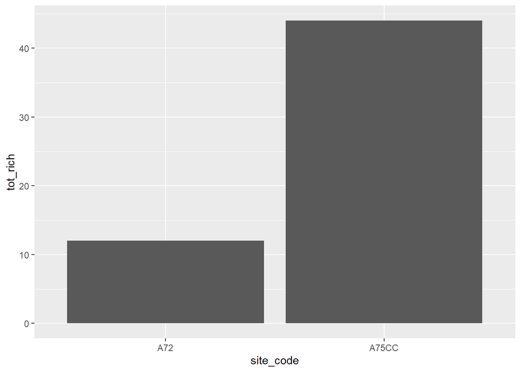

```r
ggplot(two_sites_results,
       aes(x = site_code,
           y = tot_rich)) +
  geom_bar(stat = "identity")
```

- we can also add other aesthetics, such as changing the fill to match with the impact category.
- first, we need to add the site_info back to our results object
- The site_info is stored in another sheet in your excel book
- Let’s first read that in as a new data object.

```r
site_info <- read_excel("data/MMI_HW_data.xlsx",
                        sheet = "site_info")
```

- Now we can bind that to our results and make a plot

```r
two_sites_results <- left_join(two_sites_results, site_info)
```

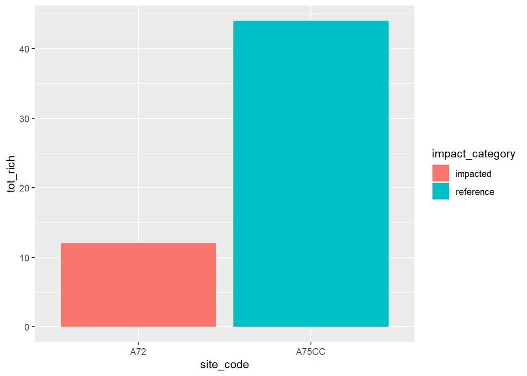

```r
ggplot(two_sites_results,
       aes(x = site_code,
           y = tot_rich,
           fill = impact_category)) +
  geom_bar(stat = "identity")
```

- we can also add a title and change the axis labels to be more descriptive
- I am also going to add a `theme_bw()` layer because I think it looks better than the defaults.

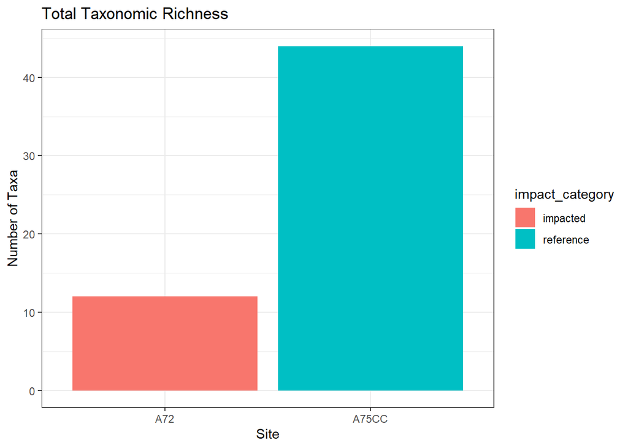

```r
ggplot(two_sites_results,
       aes(x = site_code,
           y = tot_rich,
           fill = impact_category)) +
  geom_bar(stat = "identity") +
  labs( title = "Total Taxonomic Richness",
        x = "Site",
        y = "Number of Taxa") +
  theme_bw()
```

- You can also change the color values using pre-determined color palettes
- The `viridis` palette is designed to be colorblind and grey-scale friendly, and has different palette options in it.

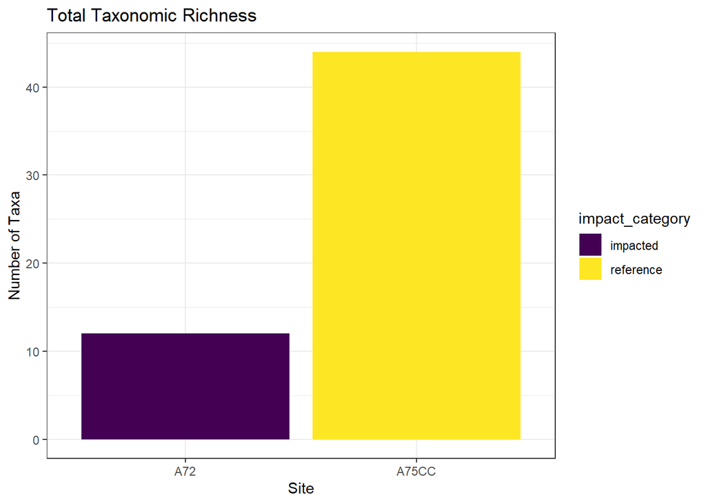

```r
ggplot(two_sites_results,
       aes(x = site_code,
           y = tot_rich,
           fill = impact_category)) +
  geom_bar(stat = "identity") +
  labs( title = "Total Taxonomic Richness",
        x = "Site",
        y = "Number of Taxa") +
  theme_bw() +
  scale_fill_viridis_d()
```

- Other color options inside of `viridis`
- Options A-H
- each option also has a name
- You can Google “Viridis palettes” for a full list of otions and examples

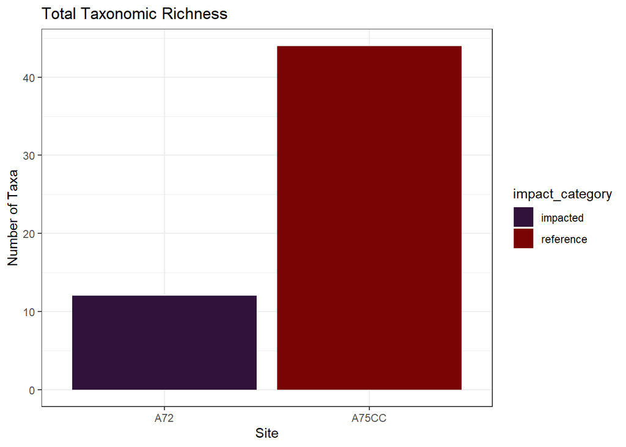

```r
ggplot(two_sites_results,
       aes(x = site_code,
           y = tot_rich,
           fill = impact_category)) +
  geom_bar(stat = "identity") +
  labs( title = "Total Taxonomic Richness",
        x = "Site",
        y = "Number of Taxa") +
  theme_bw() +
  scale_fill_viridis_d(option = "H")
```

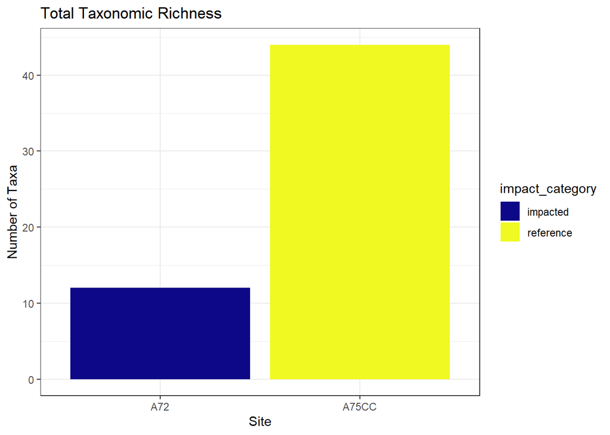

```r
ggplot(two_sites_results,
       aes(x = site_code,
           y = tot_rich,
           fill = impact_category)) +
  geom_bar(stat = "identity") +
  labs( title = "Total Taxonomic Richness",
        x = "Site",
        y = "Number of Taxa") +
  theme_bw() +
  scale_fill_viridis_d(option = "plasma")
```

### Plotting Ephemeroptera Richness

- We can modify the code to make plots of other metrics
- Change the `y =` variable for other result columns
- Be sure to update the labels appropriately.

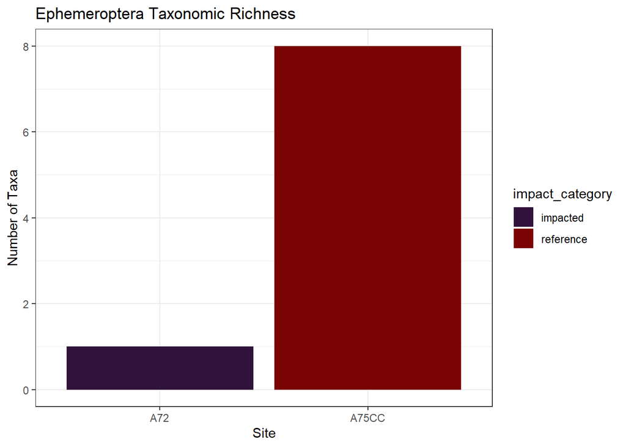

```r
ggplot(two_sites_results,
       aes(x = site_code,
           y = E_rich,
           fill = impact_category)) +
  geom_bar(stat = "identity") +
  labs( title = "Ephemeroptera Taxonomic Richness",
        x = "Site",
        y = "Number of Taxa") +
  theme_bw() +
  scale_fill_viridis_d(option = "H")
```

> Do problem 4 in single metric assignments